# 2022 Presidential Elections Data

This is a personal project that aims to analyze the Philippine 2022 Presidential Election using the programming language, R. This project is based on Project Raven’s Tableau [project](https://www.facebook.com/61562294530876/posts/pfbid02bwLWd45JfRSiCbmaFYBJRfM4WbYD6diK8rBAHRzoDjDwoZF8DWW8HZJ6gKJRhp9tl/).

My personal aim in achieving this project is to avoid using any AI for assistance to fully immerse myself with the fundamentals and avoid reliance.

This project will use the dataset from Figshare: click [here](https://figshare.com/articles/dataset/2022_Presidential_Elections_Data/19755469?file=35101492) to download the dataset.

## Setting Up the Environment

This list contains all the packages necessary for this project. To uncomment the list, press `Ctrl + Shift + C`. Feel free to continue if you have these packages installed already.

```r
# install.packages('tidyverse')
# install.packages('readr')
# install.packages('dplyr')
# install.packages('janitor')
# install.packages('ggplot2')
# install.packages('plotly')
# install.packages('scales')
# install.packages('sf')
# install.packages("tmap", repos = c("https://r-tmap.r-universe.dev",
#                                    "https://cloud.r-project.org"))
# library(tidyverse)
# library(readr)
# library(janitor)
# library(ggplot2)
# library(plotly)
# library(scales)
# library(sf)
# library(dplyr)
# library(tmap)
```

## Reading the Dataset

Importing the dataset to the dataframe. In this case, the dataset is named as presidential_election.csv, feel free to change it to your preference!

```r
pres_df <- data.frame(read_csv("presidential_election.csv"))
```

## Studying the Dataset

Here, I studied the structure of the dataset and the connection of each column to one another.

```r
# head(pres_df)
# str(pres_df)
colnames(pres_df)
```

```
 [1] "...1"              "region"            "province"          "city"              "brgy"              "precinct"
 [7] "total_votes"       "pres_1_abella"     "pres_2_de_guzman"  "pres_3_domagoso"   "pres_4_gonzales"   "pres_5_lacson"
[13] "pres_6_mangondato" "pres_7_marcos"     "pres_8_montemayor" "pres_9_pacquiao"   "pres_10_robredo"
```

## Analysis

This section will now take a closer look on the results of the 2022 election. Here, I added a dataframe that shows the candidates’ names along with their campaign colors just for reference.

```r
candidates_df <- data.frame(
  id = 1:10,
  colname = c(
    "pres_1_abella", "pres_2_de_guzman", "pres_3_domagoso", "pres_4_gonzales",
    "pres_5_lacson", "pres_6_mangondato", "pres_7_marcos",
    "pres_8_montemayor", "pres_9_pacquiao", "pres_10_robredo"
  ),
  candidate_name = c(
    "Ernesto Abella", "Leody de Guzman", "Isko Moreno Domagoso", "Norberto Gonzales",
    "Panfilo Lacson", "Faisal Mangondato", "Ferdinand Marcos Jr.",
    "Jose Montemayor Jr.", "Manny Pacquiao", "Leni Robredo"
  ),
  campaign_color = c(
    "#808080", "#FFA500", "#0074D9", "#228B22",
    "#DDDDDD", "#8B4513", "#D50000",
    "#90EE90", "#FFD700", "#FF69B4"
  ),
  stringsAsFactors = FALSE
)

colnames(candidates_df)
```

```
[1] "id"             "colname"        "candidate_name" "campaign_color"
```

### Total Votes Preview

Next, I want a quick summary of the total votes per candidate during the election.Since I have a `pres_df` containing their candidate names and notice that colname serves as the reference for both dataframe. Then, I added a column in the `candidates_df` to count all their corresponding votes throughout the country.

In this chunk, each row will be checked out based on the according `colname` from `candidates_df`. This statement translates into “sum all votes from this column.”

```r
candidates_df <- candidates_df %>%
  rowwise() %>%
  mutate(total_votes = sum(pres_df[[colname]])) %>%
  ungroup()

candidates_df %>%
  select(candidate_name, total_votes) %>%
  arrange(desc(total_votes))
```

| candidate_name | total_votes |
| --- | --- |
| Ferdinand Marcos Jr. | 31097403 |
| Leni Robredo | 14812964 |
| Manny Pacquiao | 3629270 |
| Isko Moreno Domagoso | 1899467 |
| Panfilo Lacson | 882043 |
| Faisal Mangondato | 259492 |
| Ernesto Abella | 113215 |
| Leody de Guzman | 92040 |
| Norberto Gonzales | 89076 |
| Jose Montemayor Jr. | 59922 |

### Bar Chart of 2022 Philippine Presidential Election

Now, let’s visualize that. To make the plot interactive, you can use ggplotly.

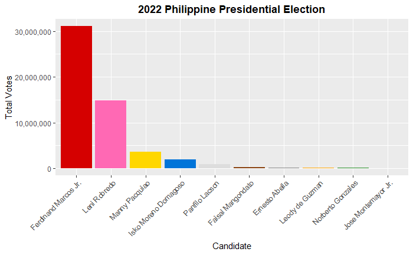

```r
ggplot(candidates_df, aes(x = reorder(candidate_name, -total_votes),
                                  y = total_votes,
                                  fill = I(campaign_color))) +
  geom_bar(stat = "identity") +
  scale_fill_identity() +
  scale_y_continuous(labels = comma) +
  labs(
    title = "2022 Philippine Presidential Election",
    x = "Candidate",
    y = "Total Votes"
  ) +
  theme (
    axis.text.x = element_text(angle = 45, hjust = 1),
    plot.title = element_text(hjust = 0.5, face = "bold")
  )
```

```r
# Assign plot to a variable named `plot`, run this code:
# ggplotly(plot)
```

### Candidate Winners per City and per Province

Now, let’s see all the city and provinces across the country and see which candidates they voted most.

```r
city_winners <- pres_df %>%
  group_by(city) %>%
  summarize(across(all_of(candidates_df$colname), sum, na.rm = TRUE)) %>%
  rowwise() %>%
  mutate(city_winner = candidates_df$colname[which.max(c_across(all_of(candidates_df$colname)))]) %>%
  ungroup()

provincial_winners <- pres_df %>%
  group_by(province) %>%
  summarize(across(all_of(candidates_df$colname), sum, na.rm = TRUE)) %>%
  rowwise() %>%
  mutate(provincial_winner = candidates_df$colname[which.max(c_across(all_of(candidates_df$colname)))]) %>%
  ungroup() %>%
  left_join(select(candidates_df, colname, campaign_color), by = c("provincial_winner" = "colname"))
```

### Getting GeoJSON of the country’s regions

What we want to do is color each region of the country based on which candidate was voted the most. With the current dataset, that is not possible so we need to find a way to find and locate each region. Luckily, we have that information online: click [here](https://gadm.org/download_country.html) to download the country’s (level 2) GeoJSON.

```r
ph_geo <- st_read("PH_GeoJSON.json")
# colnames(ph_geo)
```

Great, now we have the geometry coordinates of the cities. Note that the cities in `PH_GeoJSON`, the city column is named NAME_2, in sentence casing, and no spaces. We need to fix that first to be able to merge the two dataframes.

Let’s first clean both dataframe’s city column by creating a new column to turn both `pres_df(city)` and `ph_geo(NAME_2)` to lowercase and named `city_clean`

```r
pres_df <- pres_df %>%
    mutate(city_clean = str_to_lower(str_replace_all(city, "\\s+", ""))) %>%
    mutate(province_clean = str_to_lower(str_replace_all(province, "\\s+", "")))

ph_geo <- ph_geo %>%
    mutate(city_clean = str_to_lower(str_replace_all(NAME_2, "\\s+", ""))) %>%
    mutate(province_clean = str_to_lower(str_replace_all(NAME_1, "\\s+", "")))

city_winners <- city_winners %>%
    mutate(city_clean = str_to_lower(str_replace_all(city, "\\s+", "")))

provincial_winners <- provincial_winners %>%
    mutate(province_clean = str_to_lower(str_replace_all(province, "\\s+", "")))
```

Now, let’s merge the two dataframes.

```r
city_winners <- city_winners %>%
  # In the city winners, you'll be able to see the votes per city, candidate who won, their campaign color, and the city's geometry.
  left_join(select(ph_geo, city_clean, geometry), by = "city_clean") %>%
  left_join(select(candidates_df, colname, campaign_color), by = c("city_winner" = "colname"))

# Here, we need to convert the dataframe into a sf object
city_winners <- st_as_sf(city_winners, sf_column_name = "geometry")
# st_geometry(city_winners)

province_winners <- ph_geo %>%
  mutate(
    geometry = st_make_valid(geometry)  # 🧹 Clean invalid geometries
  ) %>%
  group_by(province_clean) %>%
  summarise(geometry = st_union(geometry), .groups = "drop")

province_winners <- provincial_winners %>%
  left_join(ph_geo, by = "province_clean") %>%
  st_as_sf()
```

We now have the winners per city and the coordinates of the cities. We can now do a geocomputation map.

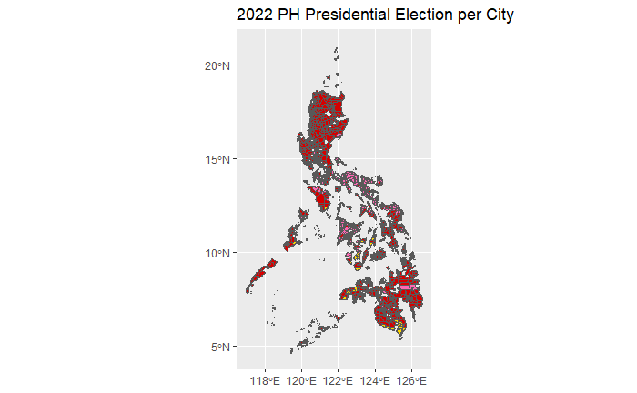

```r
ggplot(data = city_winners) +
  geom_sf(aes(fill = campaign_color), size = 0.2) +
  scale_fill_identity() +
  labs(title = "2022 PH Presidential Election per City",
       fill = "Winner")
```

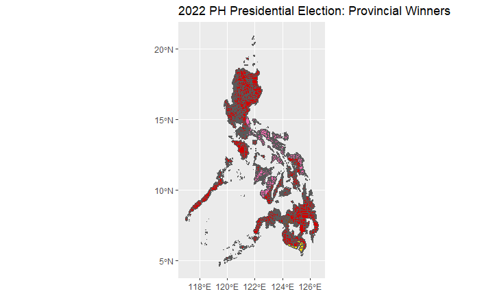

```r
ggplot(data = province_winners) +
  geom_sf(aes(fill = campaign_color), size = 0.2) +
  scale_fill_identity() +
  labs(title = "2022 PH Presidential Election: Provincial Winners",
       fill = "Winner")
```